# Chapter 2 Simple Linear Regression (Exercises)

Tianhai Zu(zuti@mail.uc.edu)

**Acknowledgment**: the materials below are partially based on Montgomery, D. C., Peck, E. A., Vining, G. G., Introduction to Linear Regression Analysis (5th Edition), Wiley Series in Probability and Statistics, 2012. This materials was initilated by Yichen Qin and modified by Tianhai Zu for teaching purpose.

### Exercise 1

For the Chicago data set, do the following analysis.

- Read data into R, use y as response and x as covariate to run a simple linear regression.
- Obtain parameter estimates of slope and intercept.
- Obtain the fitted values, compare the fitted values with the actual values by plotting one against the other.
- Obtain the residuals, and visualize its distribution.
- What are the standard error of the slops and intercept. Are they too large?
- Perform hypothesis testing for the slope, i.e., $H_0: \beta_1=0$. what is your conclusion?
- Do the same thing for the intercept, i.e., $H_0: \beta_0=0$
- Obtain the interval estimation of slope and intercept. Can you spot the connection between interval estimation and hypothesis testing in the previous questions? If you cannot, continue with the rest of the data set.
- What does `attach(...)` function do? Why do we need it?
- What does `abline(h=...)` do?

```r
d=read.csv("data_chicago.csv")
names(d)
```

```
## [1] "x" "y"
```

```r
attach(d)
plot(x,y)
model2=lm(y~x)
summary(model2)
```

```
##
## Call:
## lm(formula = y ~ x)
##
## Residuals:
##     Min      1Q  Median      3Q     Max
## -41.628  -9.028  -0.009   7.882  77.861
##
## Coefficients:
##             Estimate Std. Error t value Pr(>|t|)
## (Intercept)  16.9952     4.9949   3.403 0.001528 **
## x             1.3135     0.3144   4.177 0.000155 ***
## ---
## Signif. codes:  0 '***' 0.001 '**' 0.01 '*' 0.05 '.' 0.1 ' ' 1
##
## Residual standard error: 19.46 on 40 degrees of freedom
## Multiple R-squared:  0.3037, Adjusted R-squared:  0.2863
## F-statistic: 17.45 on 1 and 40 DF,  p-value: 0.0001553
```

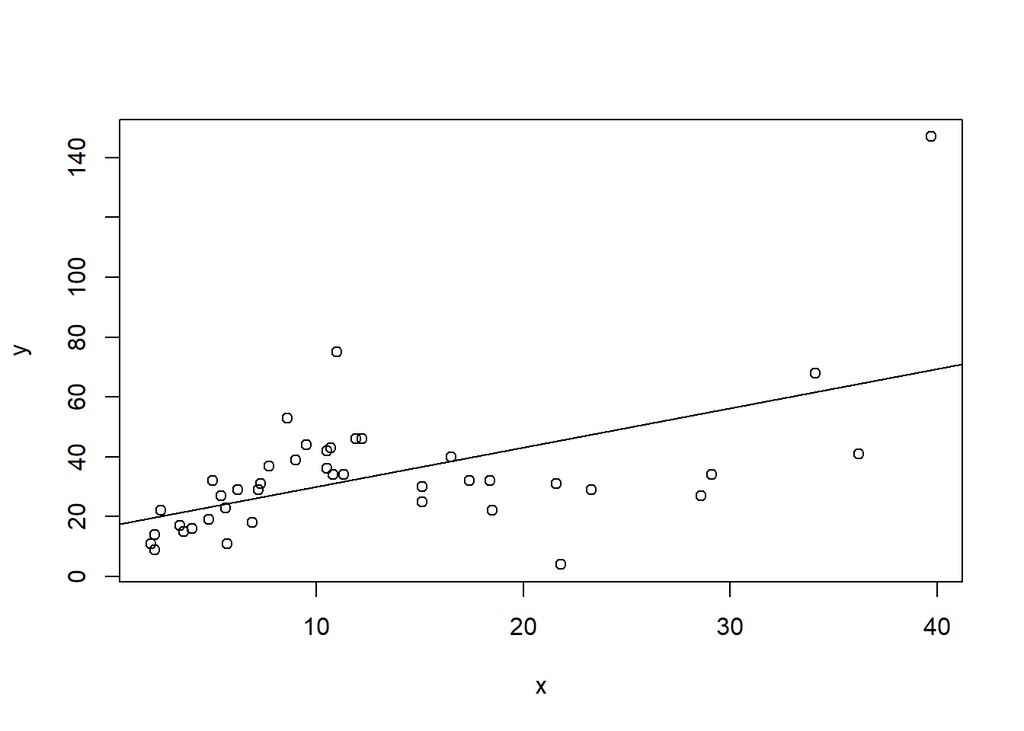

```r
abline(model2)
```

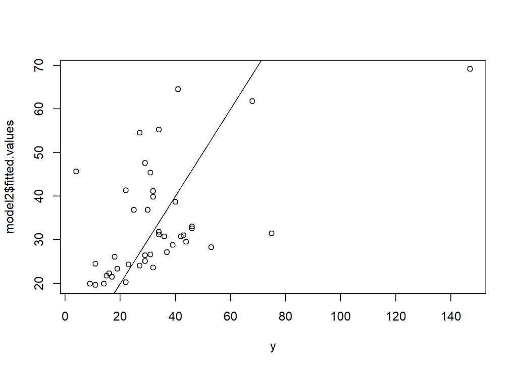

```r
plot(y,model2$fitted.values)
abline(a=0,b=1)
```

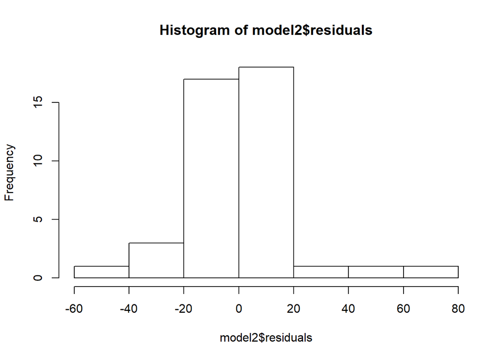

```r
hist(model2$residuals)
```

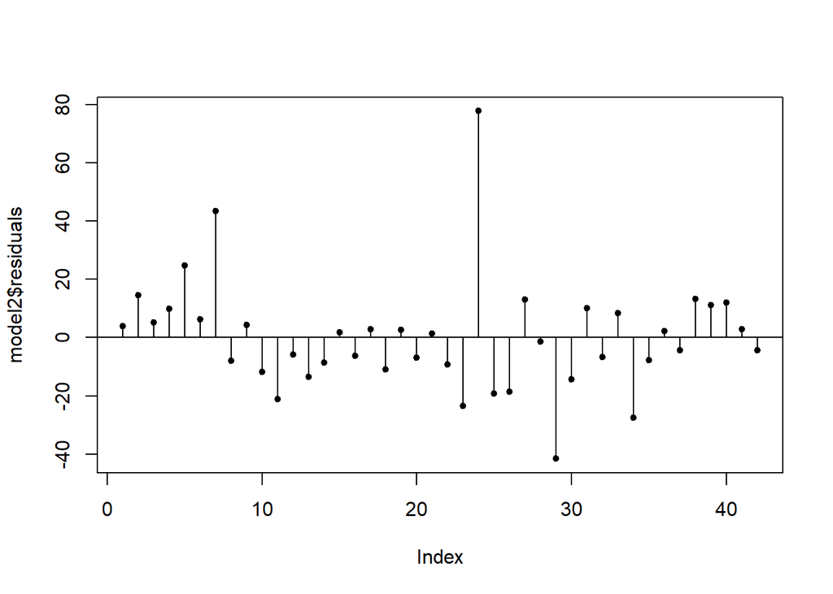

```r
plot(model2$residuals,pch=20)
points(model2$residuals,type="h")
abline(h=0)
```

```r
confint(model2,level=0.95)
```

```
##                 2.5 %    97.5 %
## (Intercept) 6.9001268 27.090188
## x           0.6779667  1.948945
```

```r
detach(d)
```

### Exercise 2

For the Delta Airlines data set, repeat the same question as in Exercise 1.

```r
d=read.csv("data_delta.csv")
names(d)
```

```
## [1] "Day.of.month"            "Flight.Number"
## [3] "Tail.Number"             "Destination.airport"
## [5] "Airborne.time..minutes." "Distance...miles."
```

```r
names(d)[5]="Time"
names(d)[6]="Dist"
attach(d)
plot(Dist,Time)
model3=lm(Time~Dist)
summary(model3)
```

```
##
## Call:
## lm(formula = Time ~ Dist)
##
## Residuals:
##     Min      1Q  Median      3Q     Max
## -72.981  -4.217  -0.542   4.253  83.151
##
## Coefficients:
##              Estimate Std. Error t value Pr(>|t|)
## (Intercept) 9.5556457  0.1147633   83.26   <2e-16 ***
## Dist        0.1264290  0.0001282  985.85   <2e-16 ***
## ---
## Signif. codes:  0 '***' 0.001 '**' 0.01 '*' 0.05 '.' 0.1 ' ' 1
##
## Residual standard error: 9.004 on 17721 degrees of freedom
## Multiple R-squared:  0.9821, Adjusted R-squared:  0.9821
## F-statistic: 9.719e+05 on 1 and 17721 DF,  p-value: < 2.2e-16
```

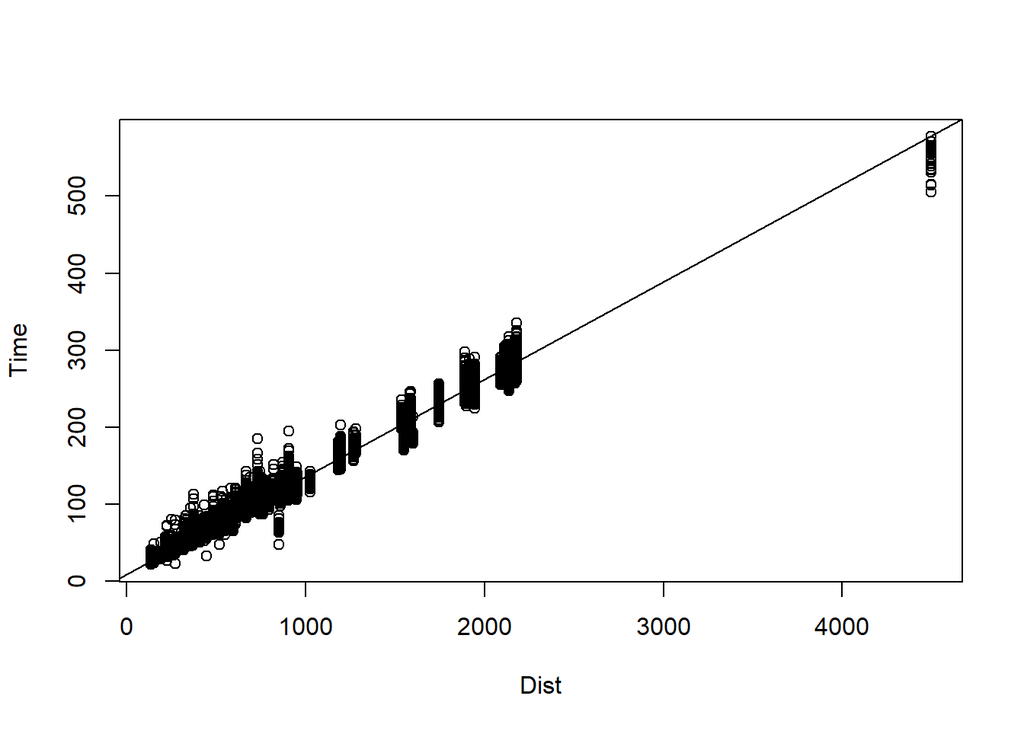

```r
abline(model3)
```

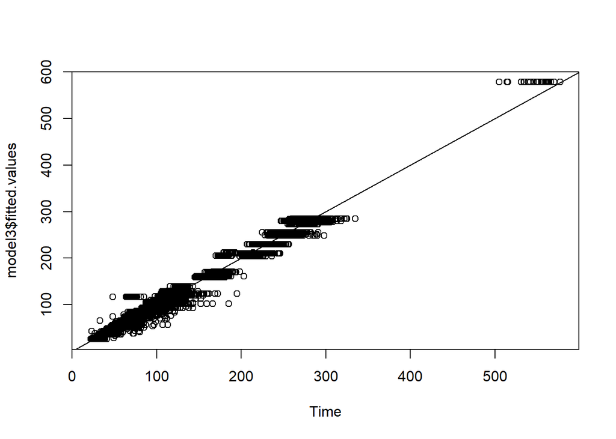

```r
plot(Time,model3$fitted.values)
abline(a=0,b=1)
```

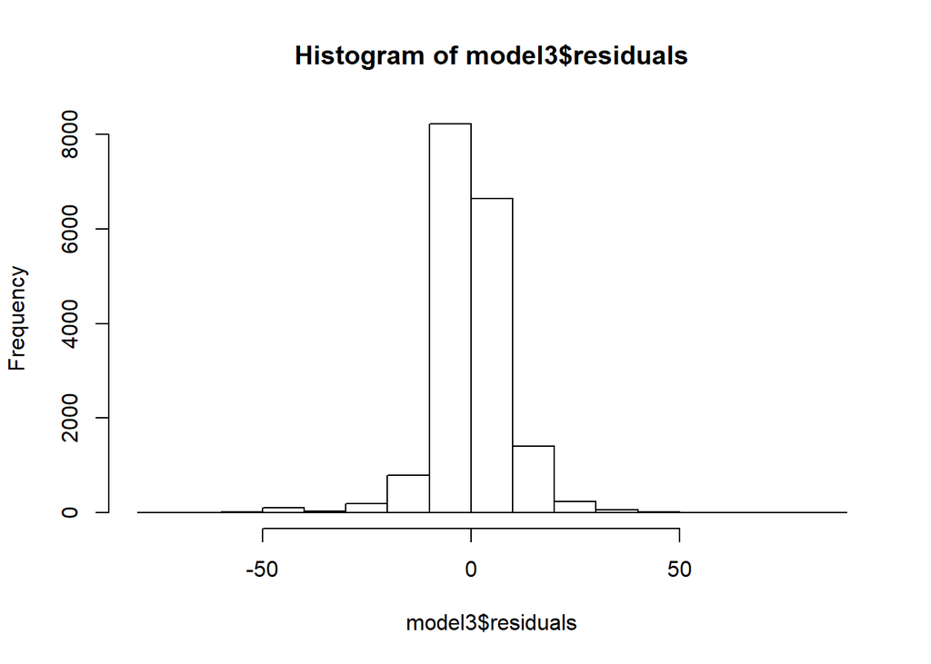

```r
hist(model3$residuals)
```

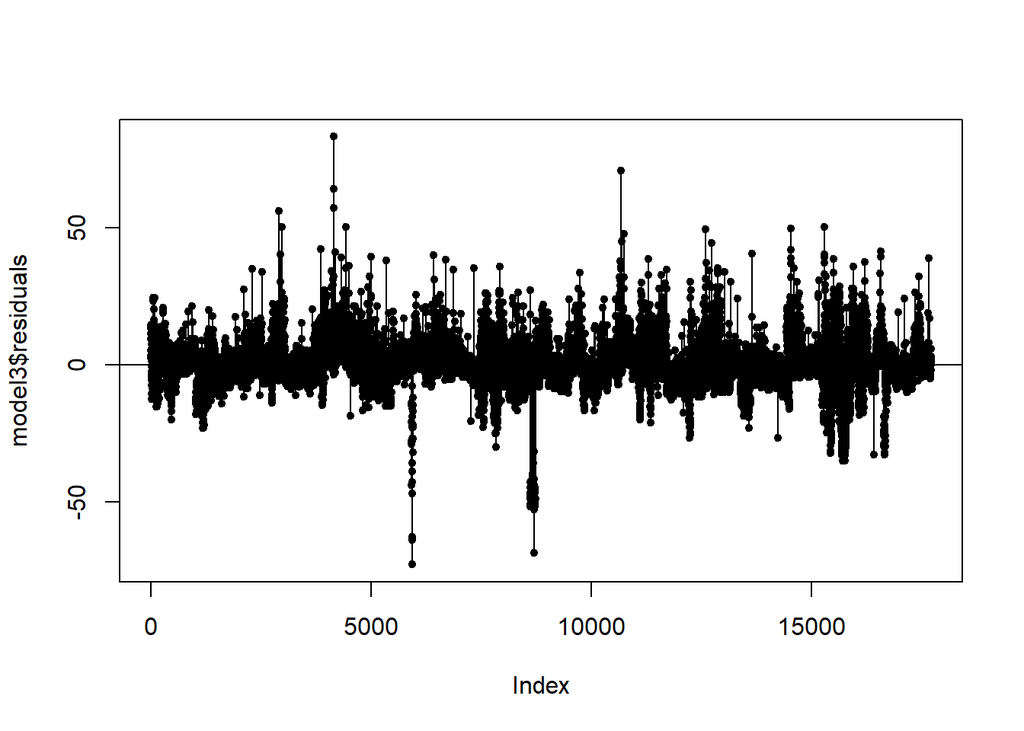

```r
plot(model3$residuals,pch=20)
points(model3$residuals,type="h")
abline(h=0)
```

```r
confint(model3,level=0.95)
```

```
##                 2.5 %    97.5 %
## (Intercept) 9.3306984 9.7805931
## Dist        0.1261777 0.1266804
```

```r
detach(d)
```

### Exercise 3

For the Vote data set, repeat the same question as in Exercise 1.

```r
d=read.csv("data_vote.csv")
names(d)
```

```
## [1] "Congress"                 "Beginning.Year"
## [3] "Average.Party.Unlikeness" "X..Party.Votes"
```

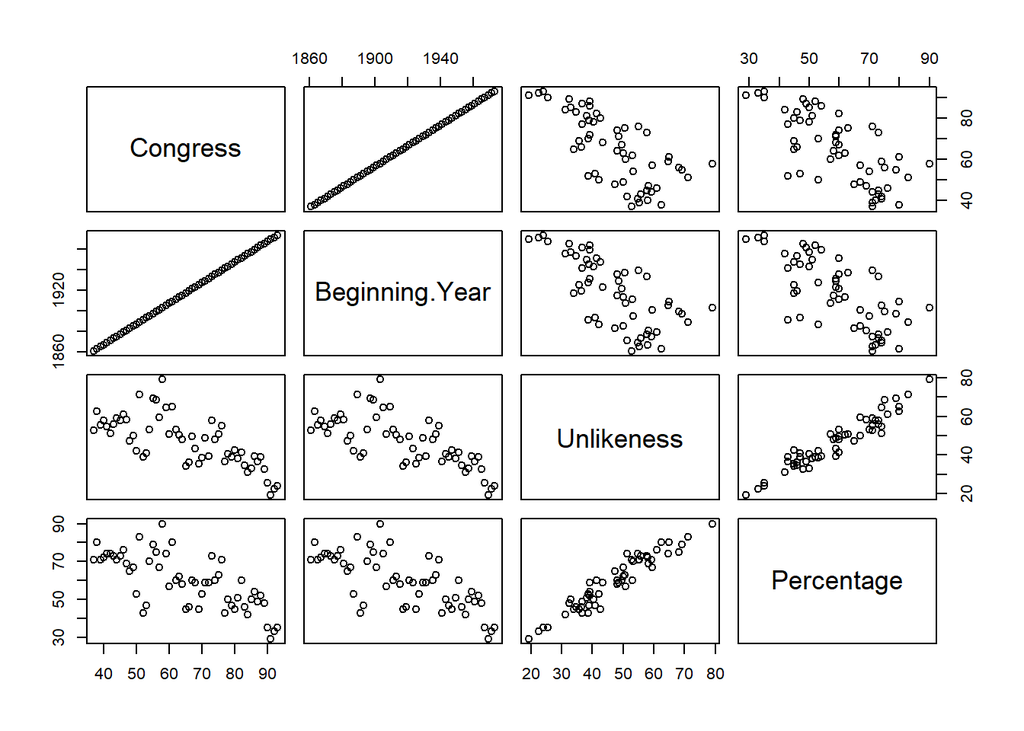

```r
names(d)[3]="Unlikeness"
names(d)[4]="Percentage"
pairs(d)
```

```r
attach(d)
model4=lm(Percentage~Unlikeness)
summary(model4)
```

```
##
## Call:
## lm(formula = Percentage ~ Unlikeness)
##
## Residuals:
##     Min      1Q  Median      3Q     Max
## -9.8444 -2.3839 -0.4884  2.8817 10.1669
##
## Coefficients:
##             Estimate Std. Error t value Pr(>|t|)
## (Intercept) 10.21475    2.13118   4.793 1.29e-05 ***
## Unlikeness   1.04519    0.04356  23.993  < 2e-16 ***
## ---
## Signif. codes:  0 '***' 0.001 '**' 0.01 '*' 0.05 '.' 0.1 ' ' 1
##
## Residual standard error: 4.197 on 55 degrees of freedom
## Multiple R-squared:  0.9128, Adjusted R-squared:  0.9112
## F-statistic: 575.7 on 1 and 55 DF,  p-value: < 2.2e-16
```

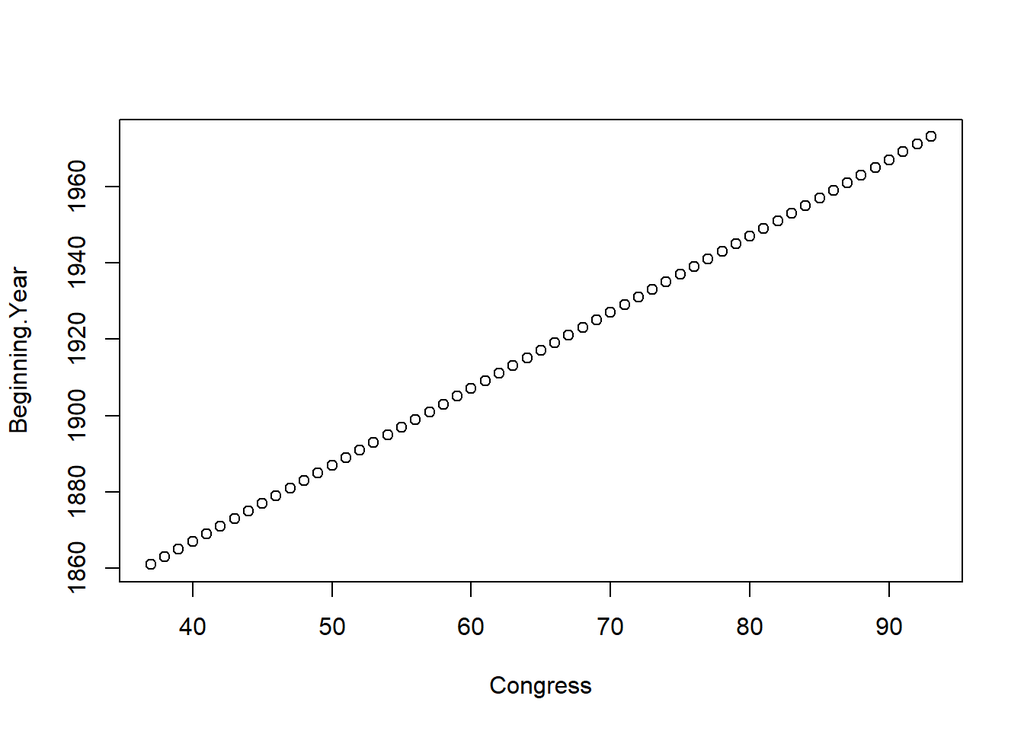

```r
plot(Congress,Beginning.Year)
abline(model4)
lines(lowess(Percentage~Unlikeness))
```

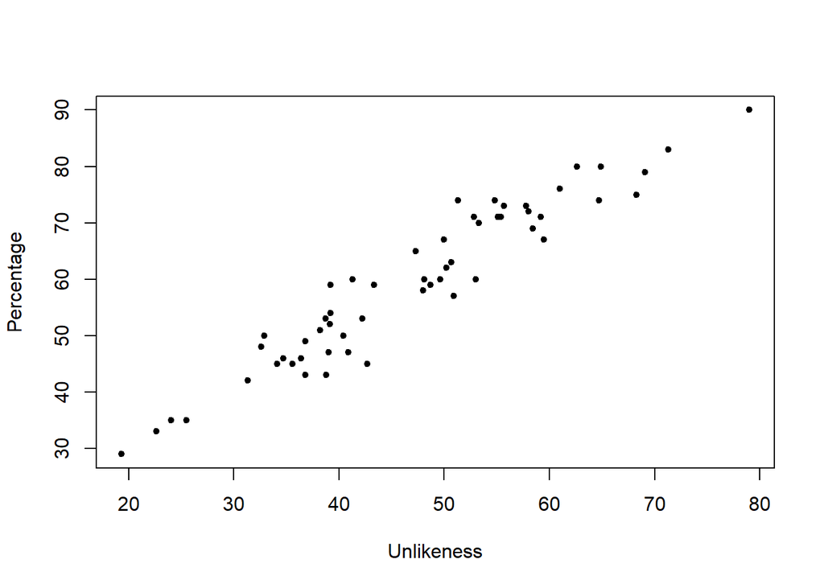

```r
plot(Unlikeness,Percentage,pch=20)
```

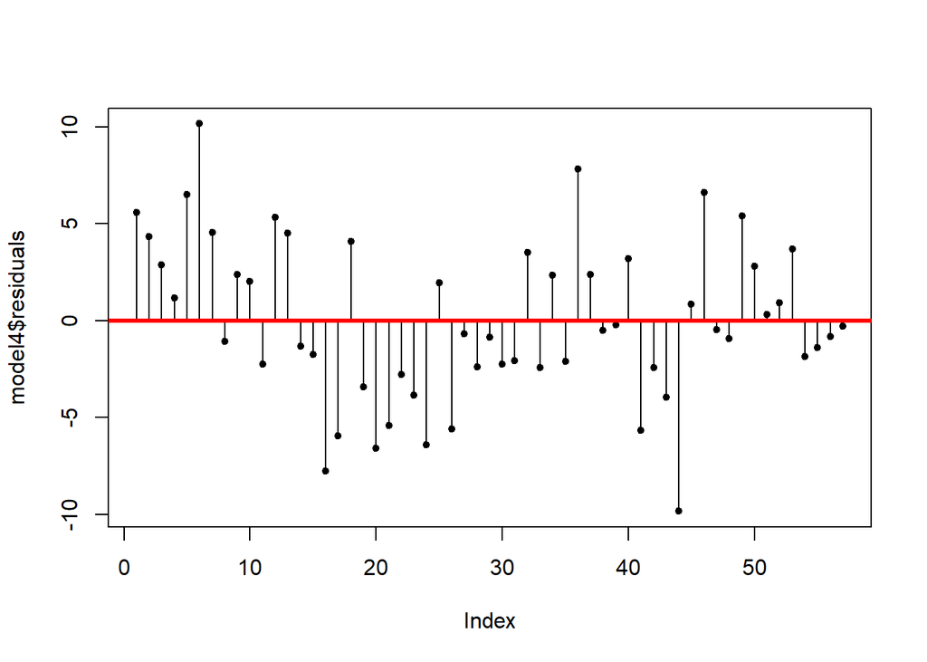

```r
plot(model4$residuals,pch=20)
points(model4$residuals,type="h")
abline(h=0,col="red",lwd=3)
```

```r
confint(model4,level=0.95)
```

```
##                 2.5 %    97.5 %
## (Intercept) 5.9437738 14.485729
## Unlikeness  0.9578917  1.132491
```